# Sample size determination

Cristian Mesquida

Eindhoven University of Technology

## Possible outcomes

|  | **Detection (Positive Result)** | **Null Result (Negative Result)** |
| --- | --- | --- |
| **Signal Present (H₁)** | **True Positive** Correct detection | **False Negative** Type II Error ($\beta$) |
| **Signal Absent (H₀)** | **False Positive** Type I Error ($\alpha$) | **True Negative** Correct rejection |

## Population vs. sample

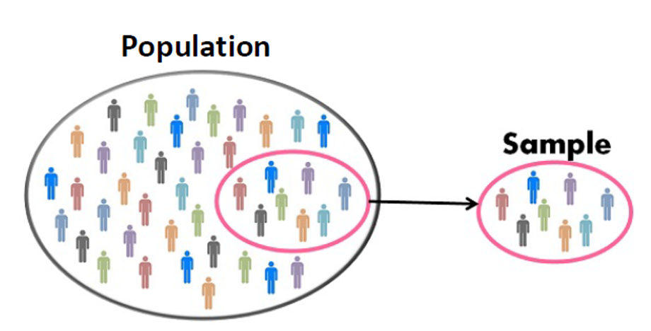

## Population vs. sample

- If we could collect data from an entire population there would be no need to perform inferential statistics
- Most often is not possible to collect data from an entire population
- Hypothesis testing as a solution

## How much data do I need?

We can answer this question with an a priori power analysis

## Statistical power

- Power can be defined as the probability of correctly detecting a true effect when it exists (1 − $\beta$)
- In frequentist statistics, it can be understood as the proportion of times we will obtain a significant result if the experiment is repeated many times.
- For example, if an experiment is repeated 100 times with 80% power, we expect to find a significant effect in approximately 80 out of those 100 studies.

## Visualizing power in the long term

- Suppose we repeat the same study 1000 times with 80% power to detect a true effect size of 0.2.
- Out of these 1000 studies, about 800 (~80%) would yield a significant *p*-value.

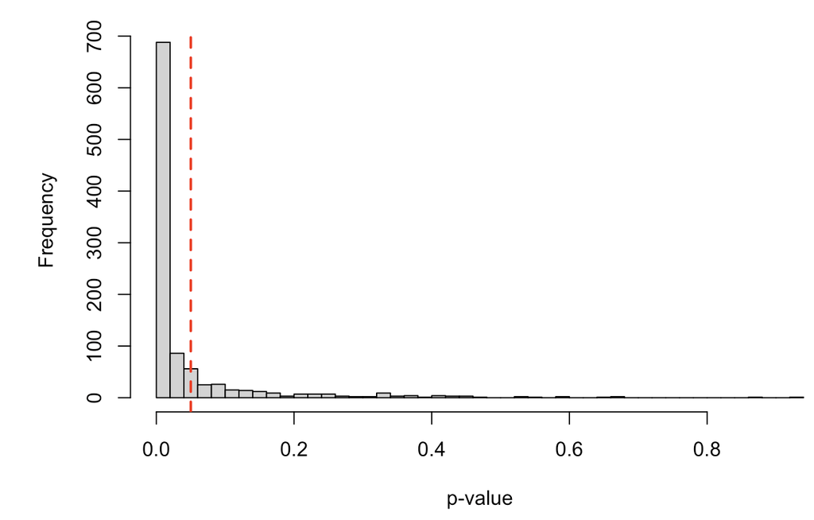

## Visualizing power in a single study

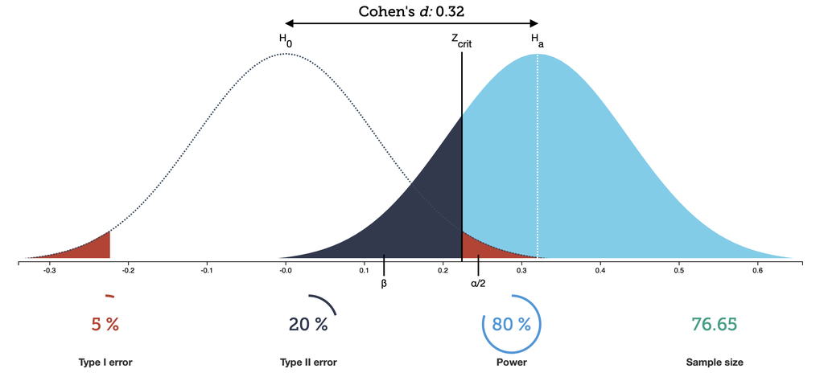

https://rpsychologist.com/d3/nhst/

## Factors determining sample size

- Effect size of interest: The larger the true effect size (difference or association), the smaller the sample size.
- Increasing mean difference or reducing the standard devaition (SD) increases effect size

  $$d = \frac{\text{mean difference}}{\text{SD}}$$
- Desired level of statistical power: A higher desired power requires a larger sample size
- $\alpha$: Lowering $\alpha$ reduces power

## Factors determining sample size

- Study design (between-subject vs. within-subject designs):
  - **Within-subject designs** (repeated measures) tend to have more power than **between-subject designs** because they reduce variability by comparing subjects to themselves.
- Directional vs. non-directional tests:
  - **One-tailed (directional)** tests have more power to detect an effect in one direction but **cannot** detect effects in the opposite direction.
  - **Two-tailed (non-directional)** tests are more conservative and split alpha across two tails, reducing power slightly for a given effect in one direction.

## Factors determining sample size

- Adding baseline covariates to an ANOVA model-resulting in an ANCOVA model-will generally increase power compared to an ANOVA model.
- ANCOVA adjusts for baseline differences between groups, reducing residual variance and thereby increasing the sensitivity to detect group differences

## Factors determining sample size

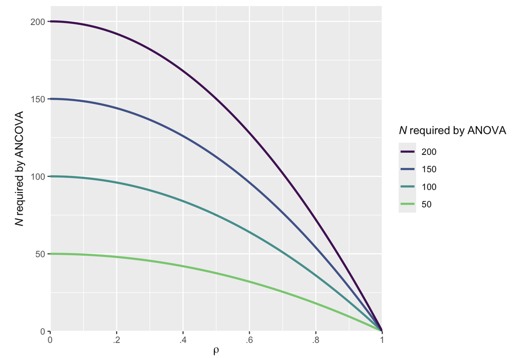

## Why high statistical power is a desired property?

- Increases the probability of finding a true effect
  - Suppose we design a study with < 50% power.
  - Not better than flipping a coin.

## Why high statistical power is a desired property?

- If a study was designed with only **30% power**, a non-significant result is generally **not informative** because it could be due to:
  - There being **no true effect**, or the effect is **smaller than expected**
  - The study having **insufficient power** to detect the effect

  In other words, low power means a non-significant result might simply reflect the study’s inability to detect existing effects rather than their absence.

## Why high statistical power is a desired property?

- Studies designed with high power yield narrower 95% confidence intervals (CIs). This improves precision and reduces uncertainty around effect sizes.

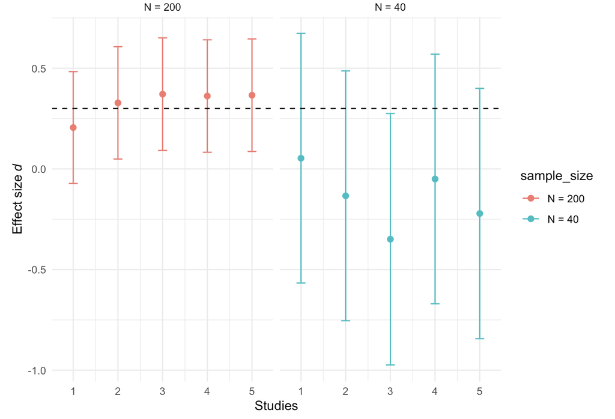

# Type of power analysis

## A priori power analysis

- Input: power, effect size, alpha level and test
- Output: sample size
- Answers the question: Given an effect size, what is the minimum sample size required to achieve the desired level of power?

## Sensitivity analysis

- Input: power, sample size, alpha level and test
- Output: effect size
- Useful when sample size is fixed due to resource constraints. For example:
  - A researcher interested in studying a very small population (Olympic athletes)
  - Financial and time constraints
- It answers the question: Given my sample size, what is the smallest significant effect size that I can detect with adequate power?

## Conducting a sensitivity analysis

- Hypothesis = Intervention A ≠ Intervention B
- Sample size = 200
- Desired level of power = 0.9
- Study design = between-subject

```r
pwr::pwr.t.test(n = 100, sig.level = 0.05, power = 0.9, type = "two.sample", alternative = "two.sided")
```

```
     Two-sample t test power calculation

              n = 100
              d = 0.4606604
      sig.level = 0.05
          power = 0.9
    alternative = two.sided

NOTE: n is number in *each* group
```

## Post hoc power analysis

- Input: observed effect size, sample size, alpha level and test
- Output: observed power
- It is bad practice: it does not add any information beyond the reported *p* value, but it presents the same information in a different way. The *p* value observed is directly related to the observed power

## Post hoc power analysis

- If the p value is non-significant (i.e., larger than 0.05) the observed power will be less than approximately 50% in a t test

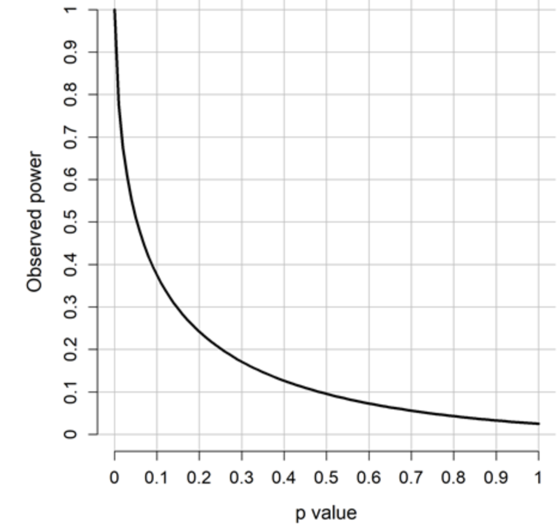

# Effect size justification

## Smallest Effect Size of Interest

- The smallest effect size that is considered theoretically and practically interesting.
- Best justification

## Expected effect size

- Previous study
- Meta-analysis
- Caveats: (1) inflated effect sizes due to publication bias and studies with underpowered designs and (2) researchers need to take into account the research context of the studies (PICOS: Population, intervention, Comparator, Outcome, Study design)

## Distribution of effect sizes in a research area

- Cohen’s *d* thresholds in psychology (*d* < 0.2 (small), *d* < 0.5 (medium), *d* > 0.5 (large))
- Suppose you want to test the difference between two treatments on weight loss. Does it make sense to justify the expected difference based on Cohen’s *d* psychologythresholds?
- It may ignore the research context (PICOS) of the study

# A priori power analysis for simple designs

## Pearson’s correlation test

- Hypothesis: Condition A related to Condition B
- Pearson’s correlation *r* = 0.4
- Study design = pre-post (within-subject)
- Desired level of power = 90%
- What is the required sample size?

```r
res <- pwr::pwr.r.test(r = 0.4, sig.level = 0.05, power = 0.9, alternative = "two.sided")

res$n
```

```
[1] 60.70866
```

## Pearson’s correlation test

- Hypothesis: Condition A positively related to Condition B
- Pearson’s correlation *r* = 0.4
- Study design = pre-post (within-subject)
- Desired level of power = 90%
- What is the required sample size?

```r
res <- pwr::pwr.r.test(r = 0.4, sig.level = 0.05, power = 0.9, alternative = "greater")

res$n
```

```
[1] 49.77286
```

## Two-sided paired *t*-test

- Hypothesis: Intervention A ≠ Intervention B
- Cohen’s *d<sub>rm</sub>* = 0.2
- Study design = pre-post (within-subject)
- Desired level of power = 90%
- What is the required sample size?

```r
res <- pwr::pwr.t.test(d = 0.2, sig.level = 0.05, power = 0.9, type = "paired", alternative = "two.sided")

res$n
```

```
[1] 264.6137
```

## One-sided paired *t*-test

- Hypothesis: Intervention A > Intervention B
- Cohen’s *d<sub>rm</sub>* = 0.2
- Study design = pre-post (within-subject)
- Desired level of power = 90%
- What is the required sample size?

```r
res <- pwr::pwr.t.test(d = 0.2, sig.level = 0.05, power = 0.9, type = "paired", alternative = "greater")

res$n
```

```
[1] 215.4562
```

## Two-sided unpaired *t*-test

- Hypothesis: Intervention A ≠ Intervention B
- Cohen’s *d<sub>s</sub>* = 0.2
- Study design = between subject
- Desired level of power = 90%
- What is the required sample size?

```r
res <- pwr::pwr.t.test(d = 0.2, sig.level = 0.05, power = 0.9, type = "two.sample", alternative = "two.sided")

res$n
```

```
[1] 526.3332
```

## One-sided unpaired *t*-test

- Hypothesis: Intervention A > Intervention B
- Cohen’s *d<sub>s</sub>* = 0.2
- Study design = between subject
- Desired level of power = 90%
- What is the required sample size?

```r
res <- pwr::pwr.t.test(d = 0.2, sig.level = 0.025, power = 0.9, type = "two.sample", alternative = "greater")

res$n
```

```
[1] 526.3334
```

# Power analysis for factorial designs

- Two or more groups/conditions
- `Superpower` package
- `Superpower:: ANOVA_exact()`: simulates an exact dataset (mu, sd, and r represent empirical, not population, parameters) from the design to calculate power
- `Superpower:: ANOVA_power()`: simulates a dataset (mu, sd, and *r* represent population paramters, mean and covariance matrix) from the design to calculate power. Similar results to `ANOVA_exact()`.

## One-way between-subject ANOVA with two levels

- Hypothesis: Intervention A ≠ Intervention B
- Cohen’s *d<sub>s</sub>* = 0.2
- Desired level of power = 90%
- What is the required sample size?

```r
string <- "2b"   # one between-subject factor with two levels
n <- 527         # sample size per condition
mu <- c(24, 26)  # expected means per group
sd <- 10         # expected standard deviation (sd)
alpha <- 0.05    # alpha level
labelnames <- c("intervention", "A", "B")

# A Cohen's d of 0.2 is calculated as follows = (26-24)/10

design_result <- Superpower::ANOVA_design(design = string, n = n, mu = mu, sd = sd, labelnames = labelnames, plot = TRUE)
```

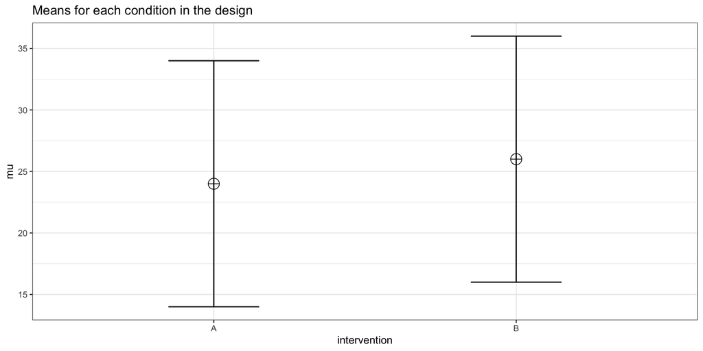

## One-way between-subject ANOVA with two levels

```r
result <- Superpower::ANOVA_exact(design_result,
                                 alpha_level = alpha,
                                 verbose = FALSE)

result$pc_results
```

```
                                   power effect_size
p_intervention_A_intervention_B 90.03604         0.2
```

## A one-way between-subject ANOVA with two levels is equivalent to a unpaired t-test

```r
res <- pwr::pwr.t.test(n = 527, d = 0.2, sig.level = 0.05, type = "two.sample", alternative = "two.sided")

res$n
```

```
[1] 527
```

## One-way within-subject ANOVA with two levels

- Hypothesis: Intervention A ≠ Intervention B
- Cohen’s *d<sub>rm</sub>* = 0.2
- Desired level of power = 90%
- What is the required sample size?

```r
string <- "2w"   # one within-subject factor with two levels
n <- 265         # sample size per condition
mu <- c(24, 26)  # expected means per group
sd <- 10         # expected standard deviation (sd)
r <- 0.5         # correlation
alpha <- 0.05    # alpha level
labelnames <- c("intervention", "A", "B")

design_result <- Superpower::ANOVA_design(design = string, n = n, mu = mu, sd = sd, r = r, labelnames = labelnames, plot = TRUE)
```

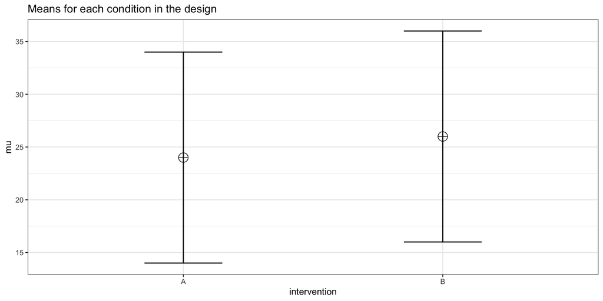

```r
result <- Superpower::ANOVA_exact(design_result,
                                 alpha_level = alpha,
                                 verbose = FALSE)

result$main_results
```

```
                power partial_eta_squared   cohen_f non_centrality
intervention 90.04175           0.0386016 0.2003784           10.6
```

## A one-way within-subject ANOVA with two levels is equivalent to a paired t-test

```r
res <- pwr::pwr.t.test(n = 265, d = 0.2, sig.level = 0.05, type = "one.sample", alternative = "two.sided")

res$n
```

```
[1] 265
```

## Two-way mixed ANOVA

- H: Intervention A ≠ Intervention B
- One between-subject factor (Intervention A vs. Intervention B) and a within-subject factor (pre vs. post)
- Effect of interest is the interaction: Does the difference between pre vs. post in Intervention A differs from Intervention B?

## Two-way mixed ANOVA

```r
string <- "2b*2w"        # two-way mixed factor with two levels
n <- 317                 # sample size per condition
mu <- c(26, 29, 25, 26)  # expected means per group
sd <- 10                 # expected standard deviation (sd)
r <- 0.7                 # correlation
alpha <- 0.05            # alpha level
labelnames <- c("intervention", "A", "B", "time", "Pre", "Post")

design_result <- Superpower::ANOVA_design(design = string, n = n, mu = mu, sd = sd, r = r, labelnames = labelnames, , plot = TRUE)
```

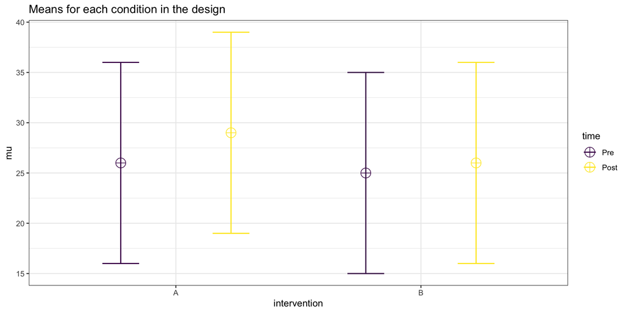

## Two-way mixed ANOVA

```r
result <- Superpower::ANOVA_exact(design_result, alpha_level = alpha, verbose = FALSE)

result$main_results
```

```
                     power partial_eta_squared   cohen_f non_centrality
intervention      77.84512          0.01166427 0.1086367       7.458824
time              99.99971          0.06268539 0.2586071      42.266667
intervention:time 90.07320          0.01644447 0.1293036      10.566667
```

## Using `ANOVA_power()`

First step is the same as in `ANOVA_exact()`

```r
string <- "2b*2w"        # two-way mixed factor with two levels
n <- 317                 # sample size per condition
mu <- c(26, 29, 25, 26)  # expected means per group
sd <- 10                 # expected standard deviation (sd)
r <- 0.7                 # correlation
alpha <- 0.05            # alpha level
labelnames <- c("intervention", "A", "B", "time", "Pre", "Post")

design_result <- Superpower::ANOVA_design(design = string, n = n, mu = mu, sd = sd, r = r, labelnames = labelnames, plot = TRUE)
```

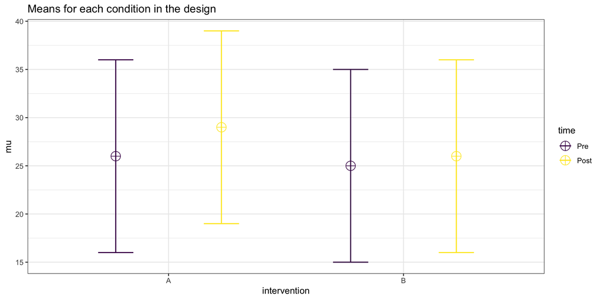

## Using `ANOVA_power()`

```r
nsims <- 1000  # number of simulations

result <- Superpower::ANOVA_power(design_result, alpha_level = alpha, nsims = nsims, verbose = FALSE)

result$main_results
```

```
                        power effect_size
anova_intervention       76.4  0.01352326
anova_time              100.0  0.06398110
anova_intervention:time  90.6  0.01822024
```